# Data analytics for economists: Assignment I

## 4.3 Principal component

```r
require(pls)
set.seed(1212)
K <- 40
pcr_cv <- pcr(wage_eur ~ ., data = Intrain, validation = "CV", segments = K)
summary(pcr_cv)
```

```
## Data:    X dimension: 7700 83
##  Y dimension: 7700 1
## Fit method: svdpc
## Number of components considered: 83
##
## VALIDATION: RMSEP
## Cross-validated using 40 random segments.
##        (Intercept)  1 comps  2 comps  3 comps  4 comps  5 comps  6 comps
## CV           22819    19867    19818    19705    19690    19680    19681
## adjCV        22819    19867    19818    19705    19689    19679    19681
##        7 comps  8 comps  9 comps  10 comps  11 comps  12 comps  13 comps
## CV       19649    19644    19503     19504     19502     19371     19354
## adjCV    19649    19644    19502     19503     19501     19370     19354
##        14 comps  15 comps  16 comps  17 comps  18 comps  19 comps  20 comps
## CV        19310     19300     19289     19279     19268     19263     19257
## adjCV     19309     19300     19288     19278     19267     19262     19257
##        21 comps  22 comps  23 comps  24 comps  25 comps  26 comps  27 comps
## CV        19192     19195     19100     19098     19096     18961     18815
## adjCV     19192     19195     19099     19097     19095     18961     18813
##        28 comps  29 comps  30 comps  31 comps  32 comps  33 comps  34 comps
## CV        18813     18808     18744     18749     18736     18737     18741
## adjCV     18812     18807     18743     18747     18734     18736     18739
##        35 comps  36 comps  37 comps  38 comps  39 comps  40 comps  41 comps
## CV        18740     18742     18744     18731     18729     18721     18723
## adjCV     18738     18741     18743     18730     18728     18719     18721
##        42 comps  43 comps  44 comps  45 comps  46 comps  47 comps  48 comps
## CV        18715     18545     18240     15518     15519     15520     15518
## adjCV     18715     18543     18239     15515     15517     15518     15516
##        49 comps  50 comps  51 comps  52 comps  53 comps  54 comps  55 comps
## CV        15520     15521     15522     15523     15525     15527     15530
## adjCV     15518     15519     15520     15521     15523     15525     15528
##        56 comps  57 comps  58 comps  59 comps  60 comps  61 comps  62 comps
## CV        15530     15527     15529     15530     15530     15529     15532
## adjCV     15527     15525     15527     15528     15528     15527     15530
##        63 comps  64 comps  65 comps  66 comps  67 comps  68 comps  69 comps
## CV        15522     15522     15516     15518     15519     15523     15511
## adjCV     15520     15519     15514     15515     15517     15520     15507
##        70 comps  71 comps  72 comps  73 comps  74 comps  75 comps  76 comps
## CV        15519     15523     15526     15527     15526     15524     15526
## adjCV     15516     15520     15523     15524     15524     15521     15523
```

[output cut: 26 more lines]

```
##           50 comps  51 comps  52 comps  53 comps  54 comps  55 comps  56 comps
## X           100.00    100.00    100.00    100.00    100.00    100.00    100.00
## wage_eur     54.63     54.64     54.64     54.64     54.64     54.64     54.65
##           57 comps  58 comps  59 comps  60 comps  61 comps  62 comps  63 comps
## X           100.00    100.00     100.0    100.00    100.00    100.00    100.00
## wage_eur     54.68     54.68      54.7     54.71     54.72     54.73     54.81
##           64 comps  65 comps  66 comps  67 comps  68 comps  69 comps  70 comps
## X           100.00    100.00    100.00    100.00    100.00    100.00    100.00
## wage_eur     54.82     54.86     54.86     54.86     54.87     55.01     55.01
##           71 comps  72 comps  73 comps  74 comps  75 comps  76 comps  77 comps
## X           100.00    100.00    100.00    100.00    100.00    100.00    100.00
## wage_eur     55.03     55.04     55.04     55.06     55.08     55.08     55.08
##           78 comps  79 comps  80 comps  81 comps  82 comps  83 comps
## X           100.00    100.00    100.00    100.00    100.00    100.00
## wage_eur     55.13     55.18     55.19     55.19     55.19     55.24
```

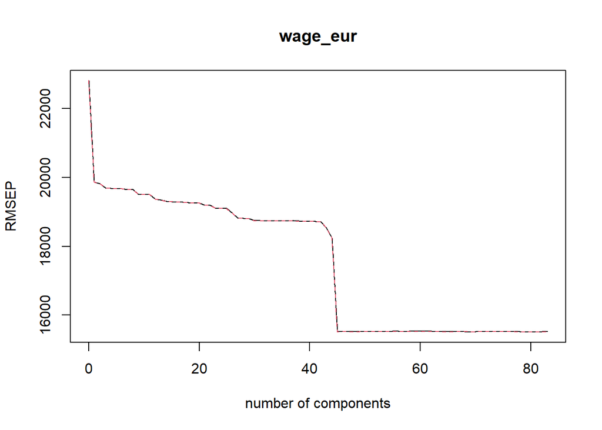

```r
plot(pcr_cv, plottype = "validation")
```

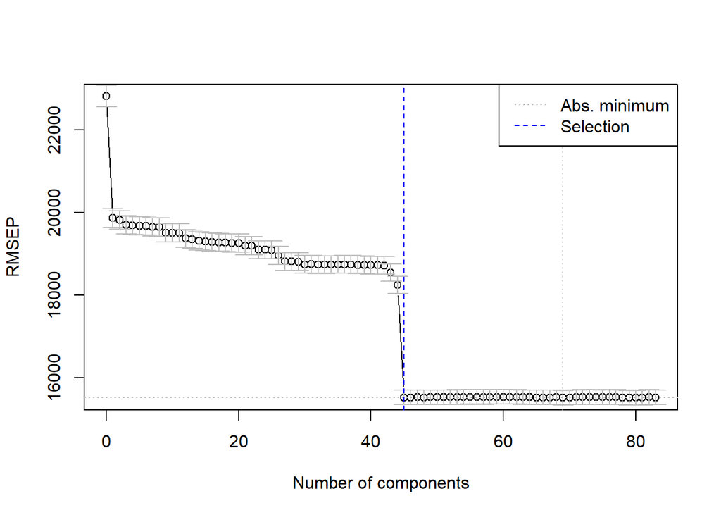

```r
##Parameter tuning and finding the n component that yields the minimum RMSE
optimal_ncomp <- selectNcomp(pcr_cv, method = "onesigma", plot = TRUE)
```

```r
MSE <- function(obs, pred){
  mean((drop(obs) - drop(pred))^2)
}
final_pcr_model <- pcr(wage_eur ~ ., data = Intrain, ncomp = optimal_ncomp)
pcr_preds <- predict(final_pcr_model, newdata = Intest, ncomp = optimal_ncomp)
sqrt(mean((Y_Intest - pcr_preds)^2))
```

```
## [1] 14631.92
```

## 4.4 Random Forest Model

```r
if (!require(randomForest)){
  install.packages("randomForest")
  library(randomForest)
}
```

```r
set.seed(1212)
RF <- randomForest(wage_eur ~ .,
                   data = Intrain[, -"player_ID"],
                   importance = TRUE,
                   mtry=16,
                   ntree=1000)
```

Importance of variable we now know the importance of variable, so if we want to go trimming next time, we know what to start

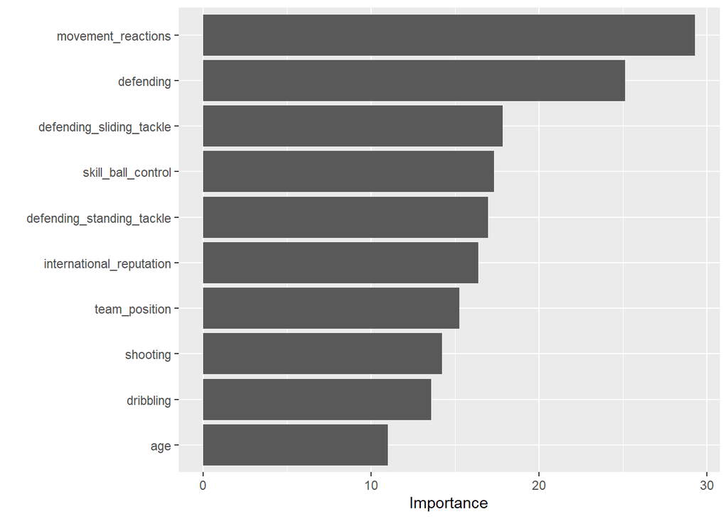

```r
if (!require(vip)){
  install.packages("vip")
  library(vip)
}
vip (RF)
```

```r
#test
Y_pred_RF <- predict(RF, Intest[ ,-"player_ID"])

mean( (Y_Intest - Y_pred_RF)^2 )
```

```
## [1] 121829419
```

```r
sqrt(mean( (Y_Intest - Y_pred_RF)^2 ))
```

```
## [1] 11037.64
```

```r
if (!require(gbm)){
  install.packages("gbm")
  library(gbm)
}
set.seed(1212)
btree <- gbm(
  formula = wage_eur ~ .,
  data = Intrain[ ,-"player_ID"],
  distribution = "gaussian",
  n.trees = 1000,
  shrinkage = 0.01,
  interaction.depth = 3,
)
```

```r
Y_pred_btree <- predict(btree, Intest[ ,-"player_ID"], n.trees=1000)
mean( (Y_Intest - Y_pred_btree)^2 )
```

```
## [1] 122023549
```

```r
sqrt(mean( (Y_Intest - Y_pred_btree)^2 ))
```

```
## [1] 11046.43
```

## 4.5 Neural Network

```r
normz <- function(x){
  (x - min(x)) / (max(x) - min(x))
}

X_Intrainorm <- apply(X_Intrain, 2, normz)
X_Intestnorm <- apply(X_Intest, 2, normz)
#
# X_train <- scale(X_train)
# X_test <- scale(X_test)
```

```r
train_df <- data.frame(cbind(Y_Intrain, X_Intrainorm))
test_df <- data.frame(X_Intestnorm)
```

```r
library(neuralnet)
```

[figure not shown]

```r
set.seed(1212)
NN.fit <- neuralnet(Y_Intrain ~ . , data=train_df, hidden=5, linear.output=TRUE)

plot(NN.fit, rep="best")
```

```r
Y_pred_NN <- predict(NN.fit, test_df)
result1 <- mean( (Y_Intest - Y_pred_NN)^2 )
sqrt(result1)
```

```
## [1] 21655.59
```

```r
library(nnet)
set.seed(1212)
NN.fit <- nnet(Y_Intrain ~ . , data = train_df, size = 5, linout = TRUE, maxit=1000, trace=FALSE)
NN.fit$convergence
```

```
## [1] 0
```

```r
Y_pred_NN <- predict(NN.fit, test_df)
result2 <- mean( (Y_Intest - Y_pred_NN)^2 )
sqrt(result2)
```

```
## [1] 21655.59
```

```r
set.seed(1212)
NN.fit <- nnet(Y_Intrain ~ . , data = train_df, size = 5, linout = TRUE, decay = 0.01, maxit=10000, trace=FALSE)
NN.fit$convergence
```

```
## [1] 0
```

```r
Y_pred_NN <- predict(NN.fit, test_df)
result <- mean( (Y_Intest - Y_pred_NN)^2 )
sqrt(result)
```

```
## [1] 21655.59
```

## 4.6 Ensemble Method

```r
set.seed(1212)
EN.fit <-  SuperLearner(Y = Y_Intrain, X = data.frame(X_Intrain[,-1]), family = gaussian(), SL.library = c("SL.mean", "SL.rpartPrune", "SL.glmnet"))
EN.fit
```

```
##
## Call:
## SuperLearner(Y = Y_Intrain, X = data.frame(X_Intrain[, -1]), family = gaussian(),
##     SL.library = c("SL.mean", "SL.rpartPrune", "SL.glmnet"))
##
##
##                        Risk      Coef
## SL.mean_All       520730709 0.0000000
## SL.rpartPrune_All 197918285 0.6021291
## SL.glmnet_All     239393501 0.3978709
```

Now, we will evaluate the Ensemble method.

```r
Y_pred_en = predict(EN.fit, data.frame(X_Intest[,-1]))

RMSE_EN <- sqrt(mean( (Y_Intest - Y_pred_en$pred)^2 ))
RMSE_EN
```

```
## [1] 12567.53
```

## 4.7 XGBoost

Here, we have tried to tune the XGBoost parameters through for loops. However, we will not reproduce it here because it takes a long time.

```r
library(xgboost)
for (i in 1:10){
  for (j in 1:20){
    for (k in 1:20){
      for (l in 1:10){
        set.seed(1212)
        xgb.fit = xgboost(data =  as.matrix(X_Intrain),
                  label = Y_Intrain,
                  max.depth = l,
                  nrounds = k*500,
                  eta = j*5/1000,
                  subsample = i/100,
                  verbose=0)

Y_pred_xgb = predict(xgb.fit, as.matrix(X_Intest))
print(sqrt(mean( (Y_Intest - Y_pred_xgb)^2 )))
      }
    }
  }
}
```

```r
library(xgboost)
set.seed(1212)
Y_Intrain_log <- log(Y_Intrain)
xgb.fit = xgboost(data =  as.matrix(X_Intrain),
                  label = Y_Intrain,
                  max.depth = 2,
                  nrounds = 5500,
                  eta = 0.01,
                  subsample = 0.01,
                  verbose=0)
Y_pred_xgb = predict(xgb.fit, as.matrix(X_Intest))
print(sqrt(mean( (Y_Intest - Y_pred_xgb)^2 )))
```

```
## [1] 9860.001
```

# 5 Reporting Results

From the above estimations, we conclude that XGboost method gives the lowest RMSE. Therefore, we decide to submit our prediction using XGboost method.

```r
X_test <- model.matrix(player_ID ~ . , test)[, -1]
X_test <- data.table(player_ID = test$player_ID, X_test)
pred_submit = predict(xgb.fit, as.matrix(X_test))
submit <- data.table(Id = test$player_ID, Predicted = pred_submit)
fwrite(submit, "./submit.csv")
```